# data_622_hw_1

Jimmy Ng

2/18/2021

## load packages, data

```r
if(!require(pacman)){install.packages("pacman"); require(pacman)}
```

```r
packages <- c('nnet', 'glue', 'broom', 'MASS', 'caret', 'InformationValue', 'Hmisc', 'kableExtra', 'corrplot', 'tidyverse', 'ROCR', 'palmerpenguins', 'mice')
pacman::p_load(char = packages)

df = penguins

df %>% head() %>% kableExtra::kable()
```

| species | island | bill_length_mm | bill_depth_mm | flipper_length_mm | body_mass_g | sex | year |
| --- | --- | --- | --- | --- | --- | --- | --- |
| Adelie | Torgersen | 39.1 | 18.7 | 181 | 3750 | male | 2007 |
| Adelie | Torgersen | 39.5 | 17.4 | 186 | 3800 | female | 2007 |
| Adelie | Torgersen | 40.3 | 18.0 | 195 | 3250 | female | 2007 |
| Adelie | Torgersen | NA | NA | NA | NA | NA | 2007 |
| Adelie | Torgersen | 36.7 | 19.3 | 193 | 3450 | female | 2007 |
| Adelie | Torgersen | 39.3 | 20.6 | 190 | 3650 | male | 2007 |

## data exploration : metadata

```r
str(df)
```

```
## Classes 'tbl_df', 'tbl' and 'data.frame':    344 obs. of  8 variables:
##  $ species          : Factor w/ 3 levels "Adelie","Chinstrap",..: 1 1 1 1 1 1 1 1 1 1 ...
##  $ island           : Factor w/ 3 levels "Biscoe","Dream",..: 3 3 3 3 3 3 3 3 3 3 ...
##  $ bill_length_mm   : num  39.1 39.5 40.3 NA 36.7 39.3 38.9 39.2 34.1 42 ...
##  $ bill_depth_mm    : num  18.7 17.4 18 NA 19.3 20.6 17.8 19.6 18.1 20.2 ...
##  $ flipper_length_mm: int  181 186 195 NA 193 190 181 195 193 190 ...
##  $ body_mass_g      : int  3750 3800 3250 NA 3450 3650 3625 4675 3475 4250 ...
##  $ sex              : Factor w/ 2 levels "female","male": 2 1 1 NA 1 2 1 2 NA NA ...
##  $ year             : int  2007 2007 2007 2007 2007 2007 2007 2007 2007 2007 ...
```

```r
df %>% group_by(species, island) %>%
    summarise(n = n())
```

```
## # A tibble: 5 x 3
## # Groups:   species [3]
##   species   island        n
##   <fct>     <fct>     <int>
## 1 Adelie    Biscoe       44
## 2 Adelie    Dream        56
## 3 Adelie    Torgersen    52
## 4 Chinstrap Dream        68
## 5 Gentoo    Biscoe      124
```

```r
with(df, ftable(species, year) %>% prop.table(., margin = 1) %>% round(., 2))
```

```
##           year 2007 2008 2009
## species
## Adelie         0.33 0.33 0.34
## Chinstrap      0.38 0.26 0.35
## Gentoo         0.27 0.37 0.35
```

```r
with(df, ftable(species, sex) %>% prop.table(., margin = 1) %>% round(., 2))
```

```
##           sex female male
## species
## Adelie          0.50 0.50
## Chinstrap       0.50 0.50
## Gentoo          0.49 0.51
```

```r
metadata = data.frame(colName = names(df)) %>%
    dplyr::mutate(dtype = sapply(df, class),
                  missing = colSums(is.na(df)),
                  unique = sapply(df, function(x) length(unique(x))))

metadata %>% kableExtra::kable()
```

| colName | dtype | missing | unique |
| --- | --- | --- | --- |
| species | factor | 0 | 3 |
| island | factor | 0 | 3 |
| bill_length_mm | numeric | 2 | 165 |
| bill_depth_mm | numeric | 2 | 81 |
| flipper_length_mm | integer | 2 | 56 |
| body_mass_g | integer | 2 | 95 |
| sex | factor | 11 | 3 |
| year | integer | 0 | 3 |

The categorical variables “sex” or “year” do not help to classify the penguins. There are 3 distinct species. Let’s just focus on the four main physiological measures, i.e. “bill_length_mm”, “bill_depth_mm”, “flipper_length_mm”, and “body_mass_g”, and see how they differ.

## data exploration : physiological measures

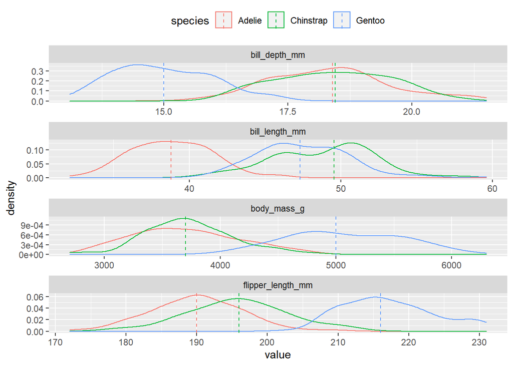

```r
bodyVars = metadata %>% dplyr::filter(unique >3) %>% .$colName %>% as.character

dfGather <- df %>%
    dplyr::select(all_of(c("species", bodyVars))) %>%
    dplyr::mutate(species = as.character(species)) %>%
    tidyr::gather(key, value, -species)

ggplot(dfGather, aes(value, color = species)) +
    geom_density() +
    theme(legend.position = "top") +
    geom_vline(data = aggregate(value ~ species + key, dfGather, median),
               aes(xintercept = value,
                   color = species),
               linetype = "dashed") +
    facet_wrap(~ key, nrow = 5, scales = "free")
```

## data cleanup : impute missing values, create binary target variable

Since Adelie and Chinstrap display similarity to each other in terms of “bill_depth_mm”, “body_mass_g” and “flipper_length_mm” (the dashed line displayed in above chart is the median), let’s group them into one category (as “AC”). Besides, Chinstrap only resides in the “Dream” island, whereas Gentoo resides only in “Biscoe” while Adelie resides in all three islands. Grouping Adelie and Chinstrap into one will make it easier to classify the penguins, e.g. knowing a penguin comes from either “Torgersen” or “Dream” would easily classify it as an “AC” penguin.

Let’s fix the missing values and come up with a new binary target variable.

```r
# impute missing values
init = mice(df, maxit = 0)
meth = init$method
predM = init$predictorMatrix
meth[c("bill_length_mm", "bill_depth_mm", "flipper_length_mm", "body_mass_g")] = "norm"
meth[c("sex")] = "logreg"

set.seed(1234)
imputed <- mice(df, method = meth, predictorMatrix = predM, m = 5)
df2 <- complete(imputed) %>%
    dplyr::mutate(target_flag = dplyr::case_when(species == "Adelie" | species == "Chinstrap" ~ 1, TRUE ~ 0),
                  target_flag = dplyr::case_when(target_flag == 1 ~ "AC", TRUE ~ "G") %>%
                          factor(., levels = c("AC", "G"), labels = c("Adelie, Chinstrap", "Gentoo"))) %>%
    dplyr::select(-species)

# double check and make sure no more missing values
colSums(is.na(df2))
```

```
##            island    bill_length_mm     bill_depth_mm flipper_length_mm
##                 0                 0                 0                 0
##       body_mass_g               sex              year       target_flag
##                 0                 0                 0                 0
```

```r
# df2 - ready to build model
df2 %>% head()
```

```
##      island bill_length_mm bill_depth_mm flipper_length_mm body_mass_g    sex
## 1 Torgersen       39.10000      18.70000           181.000    3750.000   male
## 2 Torgersen       39.50000      17.40000           186.000    3800.000 female
## 3 Torgersen       40.30000      18.00000           195.000    3250.000 female
## 4 Torgersen       44.08715      20.98134           191.335    4194.923   male
## 5 Torgersen       36.70000      19.30000           193.000    3450.000 female
## 6 Torgersen       39.30000      20.60000           190.000    3650.000   male
##   year       target_flag
## 1 2007 Adelie, Chinstrap
## 2 2007 Adelie, Chinstrap
## 3 2007 Adelie, Chinstrap
## 4 2007 Adelie, Chinstrap
## 5 2007 Adelie, Chinstrap
## 6 2007 Adelie, Chinstrap
```

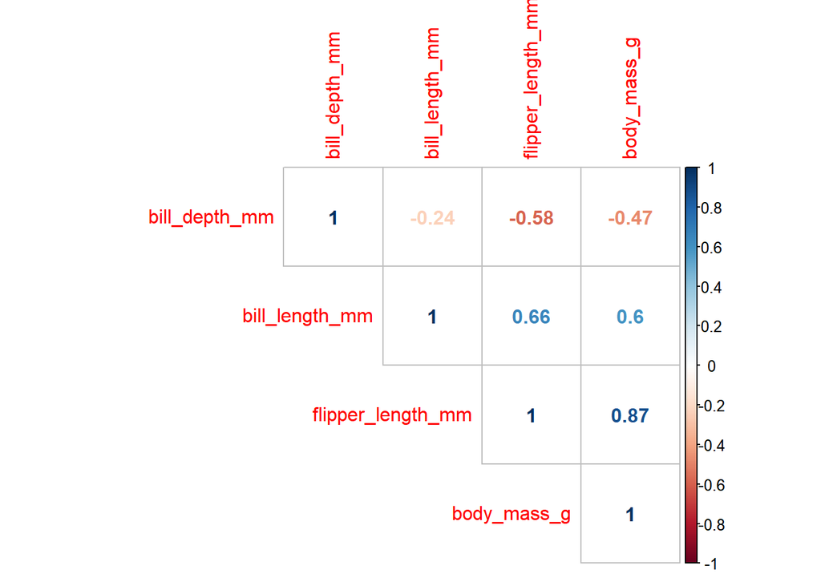

```r
# let's take a look of the bodyVars after completing the whole data set
df2 %>%
        dplyr::select(bodyVars) %>%
        cor() %>%
        corrplot(method = "number", type = "upper", order = "hclust")
## Note: Using an external vector in selections is ambiguous.
## i Use `all_of(bodyVars)` instead of `bodyVars` to silence this message.
## i See <https://tidyselect.r-lib.org/reference/faq-external-vector.html>.
## This message is displayed once per session.
```

## logistic regression : build model

Pre-process the data and then split it into train and test set.

```r
preProcValues <- caret::preProcess(df2[, bodyVars], method = c("center", "scale"))
df3 <- predict(preProcValues, df2)
set.seed(1234)
index = sample(nrow(df3), nrow(df3) * 0.7)
dfTrain <- df3[index, ]
dfTest <- df3[-index, ]
dim(dfTrain); dim(dfTest)
```

```
## [1] 240   8
## [1] 104   8
```

```r
head(dfTrain)
```

```
##     island bill_length_mm bill_depth_mm flipper_length_mm body_mass_g    sex
## 284  Dream      1.3485407     0.5255864        -0.2805527  -0.5674517   male
## 336  Dream      0.3038344     1.1313838        -0.4936580  -0.8479145 female
## 101 Biscoe     -1.6389528     0.3741371        -0.6357281  -0.5986142 female
## 111 Biscoe     -1.0707792    -0.3326265        -0.2095176  -0.4739641 female
## 133  Dream     -1.3090456     0.6770358        -0.5646930  -0.8790770 female
## 98   Dream     -0.6675592     0.6770358        -0.3515878   0.1804490   male
##     year       target_flag
## 284 2007 Adelie, Chinstrap
## 336 2009 Adelie, Chinstrap
## 101 2009 Adelie, Chinstrap
## 111 2009 Adelie, Chinstrap
## 133 2009 Adelie, Chinstrap
## 98  2008 Adelie, Chinstrap
```

```r
# full model
fullModel <- glm(target_flag ~ ., data = dfTrain, family = binomial(link = "logit"))
summary(fullModel)
```

```
##
## Call:
## glm(formula = target_flag ~ ., family = binomial(link = "logit"),
##     data = dfTrain)
##
## Deviance Residuals:
##        Min          1Q      Median          3Q         Max
## -3.694e-05  -2.100e-08  -2.100e-08   2.100e-08   2.595e-05
##
## Coefficients:
##                     Estimate Std. Error z value Pr(>|z|)
## (Intercept)        4.199e+03  6.805e+07       0        1
## islandDream       -1.028e+00  8.644e+04       0        1
## islandTorgersen   -5.117e+00  8.404e+04       0        1
## bill_length_mm     2.910e+00  3.207e+04       0        1
## bill_depth_mm     -2.022e+01  6.208e+04       0        1
## flipper_length_mm  1.262e+01  7.301e+04       0        1
## body_mass_g        1.296e+01  5.904e+04       0        1
## sexmale           -2.121e+00  6.838e+04       0        1
## year              -2.098e+00  3.387e+04       0        1
##
## (Dispersion parameter for binomial family taken to be 1)
##
##     Null deviance: 3.0412e+02  on 239  degrees of freedom
## Residual deviance: 4.1174e-09  on 231  degrees of freedom
## AIC: 18
##
## Number of Fisher Scoring iterations: 25
```

```r
# stepwise model (direction default to both)
step <- MASS::stepAIC(fullModel, trace = FALSE)
step$anova
## Stepwise Model Path
## Analysis of Deviance Table
##
## Initial Model:
## target_flag ~ island + bill_length_mm + bill_depth_mm + flipper_length_mm +
##     body_mass_g + sex + year
##
## Final Model:
## target_flag ~ bill_depth_mm + body_mass_g
##
##
##                  Step Df     Deviance Resid. Df   Resid. Dev AIC
## 1                                           231 4.117427e-09  18
## 2            - island  2 1.259859e-10       233 4.243413e-09  14
## 3              - year  1 8.010748e-11       234 4.323520e-09  12
## 4               - sex  1 5.598544e-11       235 4.379506e-09  10
## 5    - bill_length_mm  1 3.095555e-10       236 4.689061e-09   8
## 6 - flipper_length_mm  1 5.184175e-09       237 9.873236e-09   6
stepModel <- glm(target_flag ~ bill_depth_mm + body_mass_g, data = dfTrain, family = binomial(link = "logit"))
summary(stepModel)
```

```
##
## Call:
## glm(formula = target_flag ~ bill_depth_mm + body_mass_g, family = binomial(link = "logit"),
##     data = dfTrain)
##
## Deviance Residuals:
##        Min          1Q      Median          3Q         Max
## -7.374e-05  -2.100e-08  -2.100e-08   2.100e-08   6.275e-05
##
## Coefficients:
##               Estimate Std. Error z value Pr(>|z|)
## (Intercept)     -31.62   18951.68  -0.002    0.999
## bill_depth_mm   -40.41   25398.54  -0.002    0.999
## body_mass_g      33.89   18107.24   0.002    0.999
##
## (Dispersion parameter for binomial family taken to be 1)
##
##     Null deviance: 3.0412e+02  on 239  degrees of freedom
## Residual deviance: 9.8732e-09  on 237  degrees of freedom
## AIC: 6
##
## Number of Fisher Scoring iterations: 25
```

```r
# repeated, k-fold cross-validation
set.seed(1234)
train.control <- caret::trainControl(method = "repeatedcv", number = 10, repeats = 10)
kFoldModel <- caret::train(target_flag ~ bill_depth_mm + body_mass_g,
                           data = dfTrain, method = "glm", trControl = train.control)
summary(kFoldModel)
```

```
##
## Call:
## NULL
##
## Deviance Residuals:
##        Min          1Q      Median          3Q         Max
## -7.374e-05  -2.100e-08  -2.100e-08   2.100e-08   6.275e-05
##
## Coefficients:
##               Estimate Std. Error z value Pr(>|z|)
## (Intercept)     -31.62   18951.68  -0.002    0.999
## bill_depth_mm   -40.41   25398.54  -0.002    0.999
## body_mass_g      33.89   18107.24   0.002    0.999
##
## (Dispersion parameter for binomial family taken to be 1)
##
##     Null deviance: 3.0412e+02  on 239  degrees of freedom
## Residual deviance: 9.8732e-09  on 237  degrees of freedom
## AIC: 6
##
## Number of Fisher Scoring iterations: 25
```

We built 3 logistics regression models using different approaches. First, we built a full model using an entire data set. Subsequently, we applied stepwise approach and looked at both directions (forward, backward). Finally, after we came up with a final model from the stepwise approach, we applied it with kfold cross validation. We built a 10-fold, repeated (10 times) cross validation using the formula from the stepwise model (target_flag ~ bill_depth_mm + body_mass_g). We compared across the three models using Akaike Information Criterion (AIC). We acheived the lowest AIC of 6 (down from the full model of 18) and the result looks reasonable. For instance, knowing the bill_depth_mm or body_mass_g is enough for guessing whether it belongs to the AC or G type of penguins. For example, Adelie and Chinstrap have almost the same distribution of bill_depth_mm and body_mass_g, in which both of these measures are quite significantly different from Gentoo (please see above ggplot chart). Meanwhile, sex or year do not seem to have any significant predictive power.

## logistic regression : evaluation

```r
# prediction for each model
predicted_1 <- predict(fullModel, dfTest, type = "response")
predicted_2 <- predict(stepModel, dfTest, type = "response")
predicted_3 <- predict(kFoldModel, dfTest, type = "raw")

dfTest2 <- dfTest %>%
    dplyr::mutate(predicted_1 = dplyr::case_when(predicted_1 <0.5 ~ "AC", TRUE ~ "G") %>%
                     factor(., levels = c("AC", "G"), labels = c("Adelie, Chinstrap", "Gentoo")),
                  predicted_2 = dplyr::case_when(predicted_2 <0.5 ~ "AC", TRUE ~ "G") %>%
                      factor(., levels = c("AC", "G"), labels = c("Adelie, Chinstrap", "Gentoo")),
                  predicted_3 = predicted_3)

# diagnostic - Confusion Matrix, i.e. the columns are actuals, while rows are predicteds
optCutOff = 0.5
cm_1 <- InformationValue::confusionMatrix(dfTest2$target_flag, predicted = predicted_1, threshold = optCutOff)
cm_2 <- InformationValue::confusionMatrix(dfTest2$target_flag, predicted = predicted_2, threshold = optCutOff)
cm_3 <- ftable(predicted_3, dfTest2$target_flag)

# print confusion matrix
cm_1
```

```
##   Adelie, Chinstrap Gentoo
## 0                59      0
## 1                 0     45
```

```r
cm_2
```

```
##   Adelie, Chinstrap Gentoo
## 0                59      0
## 1                 0     45
```

```r
cm_3
```

```
##                    Adelie, Chinstrap Gentoo
## predicted_3
## Adelie, Chinstrap                 59      0
## Gentoo                             0     45
```

```r
# print tidy output for model evaluation
broom::tidy(caret::confusionMatrix(dfTest2$target_flag, dfTest2$predicted_2)) %>% dplyr::select(term, estimate)
```

```
## # A tibble: 13 x 2
##    term                 estimate
##    <chr>                   <dbl>
##  1 accuracy                1
##  2 kappa                   1
##  3 sensitivity             1
##  4 specificity             1
##  5 pos_pred_value          1
##  6 neg_pred_value          1
##  7 precision               1
##  8 recall                  1
##  9 f1                      1
## 10 prevalence              0.567
## 11 detection_rate          0.567
## 12 detection_prevalence    0.567
## 13 balanced_accuracy       1
```

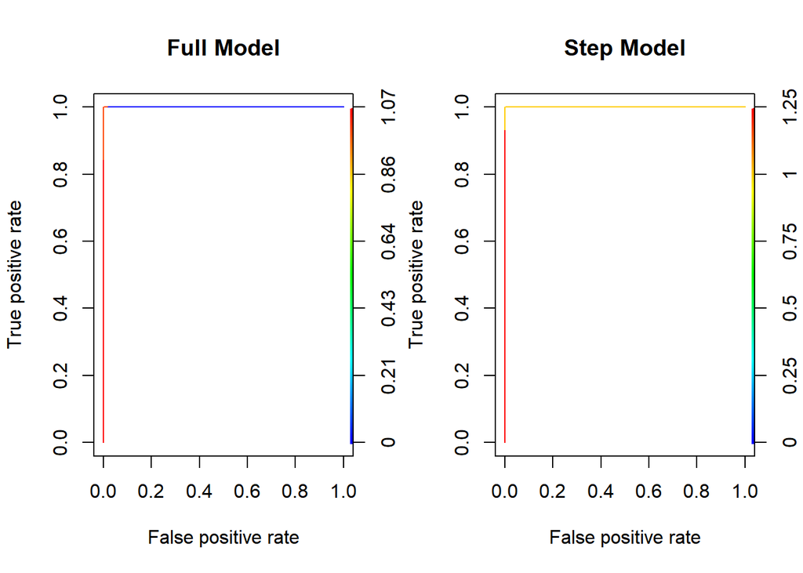

```r
# print ROC Curve
# ROC Curve
par(mfrow = c(1, 2))
pred <- prediction(predicted_1, dfTest2$target_flag)
perf <- performance(pred, "tpr", "fpr")
plot(perf, colorize = TRUE, main = "Full Model")

pred <- prediction(predicted_2, dfTest2$target_flag)
perf <- performance(pred, "tpr", "fpr")
plot(perf, colorize = TRUE, main = "Step Model")
```

```r
# Final print of the stepModel
tidy(stepModel)
```

```
## # A tibble: 3 x 5
##   term          estimate std.error statistic p.value
##   <chr>            <dbl>     <dbl>     <dbl>   <dbl>
## 1 (Intercept)      -31.6    18952.  -0.00167   0.999
## 2 bill_depth_mm    -40.4    25399.  -0.00159   0.999
## 3 body_mass_g       33.9    18107.   0.00187   0.999
```

Surprisingly, the full and stepwise models demonstrate perfect classification. We achieved 100% accuracy and the only concern is overfitting, i.e. whether our model can be applied to a different data set. For the sake of simplicity and parsimony, we should go with the simple model that is suggested by the stepwish approach. In this case, less is more. The two physiological measures are important enough to classify the penguins.

## logistic regression : print metrics

```r
pred <- prediction(predicted_2, dfTest2$target_flag)
auc = performance(pred, "auc")
auc = auc@y.values[[1]]

cm <- InformationValue::confusionMatrix(dfTest2$target_flag, predicted_2)
TN <- cm[1, 1]
FN <- cm[1, 2]
FP <- cm[2, 1]
TP <- cm[2, 2]

accuracy = (TP + TN) / (TN + FN + FP + TP)
TPR = TP / (TP + FN)
FPR = FP / (FP + TN)
TNR = TN / (TN + FP)
FNR = FN / (FN + TP)

# print the metrics
print(paste0("The AUC is ", auc * 100, "%"))
```

```
## [1] "The AUC is 100%"
```

```r
print(paste0("The Accuracy is ", accuracy * 100, "%"))
```

```
## [1] "The Accuracy is 100%"
```

```r
print(paste0("The TPR is ", TPR * 100, "%"))
```

```
## [1] "The TPR is 100%"
```

```r
print(paste0("The FPR is ", FPR * 100, "%"))
```

```
## [1] "The FPR is 0%"
```

```r
print(paste0("The TNR is ", TNR * 100, "%"))
```

```
## [1] "The TNR is 100%"
```

```r
print(paste0("The FNR is ", FNR * 100, "%"))
```

```
## [1] "The FNR is 0%"
```

## multinomial logistic regression : build model

Let’s set our baseline reference using “Adelie”. We will make prediction comparison against this baseline category.

```r
# use the original "species" column for target variable
df4 <- cbind(species = df$species, df3 %>% dplyr::select(-target_flag))

# split the data set again
train <- df4[index, ]
test <- df4[-index, ]

# set reference
train$species <- relevel(train$species, ref = "Adelie")

# build a multinomial model
multinom_model <- nnet::multinom(species ~ ., data = train)
## # weights:  30 (18 variable)
## initial  value 263.666949
## iter  10 value 0.431645
## iter  20 value 0.118350
## iter  30 value 0.066545
## iter  40 value 0.001738
## iter  50 value 0.001184
## iter  60 value 0.001128
## iter  70 value 0.000350
## iter  80 value 0.000203
## iter  90 value 0.000168
## iter 100 value 0.000108
## final  value 0.000108
## stopped after 100 iterations

# checking the model
summary(multinom_model)
```

```
## Call:
## nnet::multinom(formula = species ~ ., data = train)
##
## Coefficients:
##            (Intercept) islandDream islandTorgersen bill_length_mm bill_depth_mm
## Chinstrap -0.009096519    30.15339       -8.398646       55.21404     -29.05699
## Gentoo     0.020205059    10.96439      -39.558414       30.52027     -42.60795
##           flipper_length_mm body_mass_g   sexmale        year
## Chinstrap          12.99986   -1.689107 -21.68769 0.007679352
## Gentoo             12.57672   29.628495 -16.38241 0.011278243
##
## Std. Errors:
##           (Intercept) islandDream islandTorgersen bill_length_mm bill_depth_mm
## Chinstrap  0.04593618    23.56378    1.216616e+00       85.03581      246.2632
## Gentoo     0.08297213   182.22304    1.120212e-09       85.52528      156.0239
##           flipper_length_mm body_mass_g   sexmale      year
## Chinstrap          91.85039    86.82316  21.59739 0.1257196
## Gentoo             79.53957    95.96933 177.23002 0.1786416
##
## Residual Deviance: 0.0002168773
## AIC: 36.00022
```

```r
# convert the coefficients to odds by taking the exponential of the coefficients
options(scipen=999)
exp(coef(multinom_model)) %>% round(3)
```

```
##           (Intercept)       islandDream islandTorgersen
## Chinstrap       0.991 12458078068075.14               0
## Gentoo          1.020          57779.79               0
##                     bill_length_mm bill_depth_mm flipper_length_mm
## Chinstrap 953128158450511633206206             0          442351.7
## Gentoo              17979766914983             0          289733.8
##                 body_mass_g sexmale  year
## Chinstrap             0.185       0 1.008
## Gentoo    7370413889469.455       0 1.011
```

```r
# take a look of the predicted probability, comparing it to the original label (or target)
round(fitted(multinom_model), 2) %>% as.data.frame() %>% dplyr::mutate(species = train$species) %>%
    dplyr::select(true_label = species, everything()) %>%
    head(10) %>%
        kableExtra::kable()
```

| true_label | Adelie | Chinstrap | Gentoo |
| --- | --- | --- | --- |
| Chinstrap | 0 | 1 | 0 |
| Chinstrap | 0 | 1 | 0 |
| Adelie | 1 | 0 | 0 |
| Adelie | 1 | 0 | 0 |
| Adelie | 1 | 0 | 0 |
| Adelie | 1 | 0 | 0 |
| Adelie | 1 | 0 | 0 |
| Gentoo | 0 | 0 | 1 |
| Adelie | 1 | 0 | 0 |
| Chinstrap | 0 | 1 | 0 |

## multinomial logistic regression : evaluation

```r
# model evaluation using the test set
test$speciesPredicted <- predict(multinom_model, newdata = test, "class")

# classification table
tab <- table(test$species, test$speciesPredicted)
tab
```

```
##
##             Adelie Chinstrap Gentoo
##   Adelie        40         1      0
##   Chinstrap      0        18      0
##   Gentoo         0         0     45
```

```r
# calculate accuracy - sum of diagonal elements divided by total obs
print(paste0("The model accuracy is ", round((sum(diag(tab))/sum(tab))*100,2), "%"))
```

```
## [1] "The model accuracy is 99.04%"
```

We built almost a perfect model achieving the accuracy of 99%. The best fit statistics for evaluating the model would be accuracy as it is simple and easy to calculate. The classification table is also important in telling us the performance of our model. Relative risks or odds ratio is also important in interpreting the coefficients to people with no statistical background, such as keeping all variables constant, if your X score increases by 1 unit, you are 0.85 times more likely to be in the Z category as compared to the ref group (the risk or odds is 15% lower). Last but not least, we can perform a chi-square goodness of fit test to compare across models.